# MSDS 458 Assignment 1 (Experiment 3) April 11

DATE: April 11, 2020

## Assignment 1:

In this assignment, we construct **dense neural networks** for classifying images from the `MNIST` dataset: http://yann.lecun.com/exdb/mnist/. The MNIST database consists of a set of 70,000 small (28x28 pixel) grayscale images of digits handwritten by high school students and employees of the US Census Bureau. Each image is labeled with the digit it represents.

> In **EXPERIMENTS 1 to 3**, we consider `dense neural network` models with one hidden layer. We start with one node in this hidden layer and progressively increase the number of (hidden) nodes in the layer until we find the "best" model in Experiment 3.

But our goal in these `three` experiments is *not only* to find the "best" `dense neural network` model with one hidden but *also* to explore what the node(s) in the hidden layer are "detecting" and what their outputs (i.e. `activation values`) contribute to the final classification of an image. These are examples of intrinsic `global explanations` and `local explanations` , respectively, as described in this recent survey article:

https://cacm.acm.org/magazines/2020/1/241703-techniques-for-interpretable-machine-learning/fulltext

To determine what the hidden node is "detecting" we use gradient descent to find a visual pattern that maximizes the activation value of the hidden node, i.e. the visual pattern that the hidden node is maximally responsive to. In this case, the exercise is probably not very insightful. But in `Assignment 2` we will repeat this analysis with "clusters of nodes" (`convnet filters`) in `convolutional neural network` models. By the examining the patterns that each convnet filter is maximally responsive (but also by visualizing the convnet activations for particular test images) we should be able to determine what (some of) the filters in the `CCN` model are up to. The (activation values of the) hidden nodes (actually, groups of hidden nodes corresponding or *convnet filters*) can be visualized in various ways to show what "features" (edges, texture, etc.) of the input images they capture.

> In **EXPERIMENT 4** we use PCA decomposition to reduce the number of dimensions of our training set of 28x28 dimensional MNIST images from 784 to 154 (with 95% of training images variance lying along these components). We also reduce the number of dimensions of 'best' model from `Experiment 3` to 154 inputs nodes and train it on the new lower dimensional data.

> In **EXPERIMENT 5** we use a Random Forest classifier to get the relative importance of the 784 features (pixels) of the 28x28 dimensional images in training set of MNIST images and select the top 70 features (pixels). We train our 'best' `dense neural network` using these 70 features and compare its performance to the the `dense neural network` models from EXPERIMENTS 3 and 4.

Here are more details for the first `three` experiments:

- **EXPERIMENT 1**: Our `dense neural network` will consist of 784 input nodes, a hidden layer with `1 node` and 10 output nodes (corresponding to the 10 digits). We use `mnist.load_data()` to get the 70,000 images divided into a set of 60,000 training images and 10,000 test images. We hold back 5,000 of the 60,000 training images for validation. After training the model, we group the 60,000 `activation values` of the hidden node for the (original) set of training images by the 10 predicted classes and visualize these sets of values using a `boxplot`. We expect the overlap between the range of values in the "boxes" to be minimal. In addition, we find the pattern that maximally activates the hidden node as a "warm up" exercise for similar analysis we will perform on `CNN` models in `Assignment 2`.
- **EXPERIMENT 2**: This time our `dense neural network` will have 784 input nodes, a hidden layer with `2 nodes` and 10 output nodes (corresponding to the 10 digits). For each of the 60,000 images, the output of the two hidden nodes are plotted using a `scatterplot`. We color code the points according to which of the 10 classes the the output of the two nodes predicts. Ideally, just like in `EXPERIMENT 1`, the color clusters should have very little overlap.

**NOTE**: For EXPERIMENTS 1 & 2 we also perform the following additional tasks:

> 1. We use Matplotlib to create 2 plots--displaying the training and validation loss (resp. accuracy) for each (training) epoch side by side.
> 2. For each model we obtain the confusion matrix and use it to display sample images of true vs false positives and negatives.
- **EXPERIMENT 3**: Students can experiment with more hidden nodes (in the hidden layer) to obtain the `best` model. This `final` model will be used in EXPERIMENTS 4 & 5.

**References**: https://github.com/fchollet/deep-learning-with-python-notebooks (2.1 & 5.4)

## Import packages needed (and set seed)

Since Keras in part of TensorFlow 2.x, we import keras from tensorflow and use tenserflow.keras.xxx to import all other Keras packages. The seed argument produces a deterministic sequence of tensors across multiple calls.

```python
import numpy as np
import pandas as pd
import tensorflow as tf
from tensorflow import keras
keras.__version__
```

```
'2.2.4-tf'
```

```python
tf.__version__
```

```
'2.1.0'
```

```python
import numpy as np
keras.backend.clear_session()
np.random.seed(42)
tf.random.set_seed(42)
```

## The MNIST dataset

The MNIST dataset of handwritten digits has a training set of 60,000 examples, and a test set of 10,000 examples. It comes prepackaged as part of tf.Keras. Use the `mnist.load_data()` to the get these datasets (and the corresponding labels) as Numpy arrays.

```python
from tensorflow.keras.datasets import mnist

(train_images, train_labels), (test_images, test_labels) = mnist.load_data()
```

# EXPERIMENT 3:

We want to select the *best* `DNN` model subject to some the following restriction on `hyperparameters`:

- The number of hidden layers will be one.

We will use `sklearn.grid_search.GridSearchCV` to find the `best` number of neurons for the hidden layer.

As before we will need 784 input nodes and 10 output nodes (corresponding to the 10 digits). We use `mnist.load_data()` to get the 70,000 images divided into a set of 60,000 training images and 10,000 test images. We hold back 5,000 of the 60,000 training images for validation.

## Preparing the data

Before training, we will preprocess our data by reshaping it into the shape that the network expects, and scaling it so that all values are in the [0, 1] interval.

Our training images are stored in an array of shape (60000, 28, 28) of type uint8 with values in the [0, 255] interval.

We transform it into a float32 array of shape (60000, 28 * 28) with values between 0 and 1.

```python
train_images = train_images.reshape((60000, 28 * 28))
train_images = train_images.astype('float32') / 255

test_images = test_images.reshape((10000, 28 * 28))
test_images = test_images.astype('float32') / 255
```

## Validating our approach

We set apart 5,000 samples of our training data to use as a validation set. Since we will be using `sparse_categorical_crossentropy` as the loss function we **do not** need to use `to_categorical` to convert the class vector of labels to binary matrix representation.

```python
val_images, train_images = train_images[:5000], train_images[5000:]
val_labels, train_labels = train_labels[:5000], train_labels[5000:]
```

## Fine-Tuning the Hyperparameters

We adapt the code from Chapter 10 of Hands-On Machine Learning with Scikit-Learn, Keras & TensorFlow by A. Geron:

https://github.com/ageron/handson-ml2/blob/master/10_neural_nets_with_keras.ipynb

See also https://learning.oreilly.com/library/view/hands-on-machine-learning/9781492032632/ch10.html.

We define a `build_model` function to create a `DNN` model with a given number of hidden layers and a fixed given number of nodes per hidden layer. (What if we wanted the number of nodes to vary by layer?)

```python
from tensorflow.keras import models
from tensorflow.keras import layers

def build_model(n_hidden=1, n_neurons=2, learning_rate=0.001, input_shape=(28 * 28,)):
    model = models.Sequential()
    model.add(layers.InputLayer(input_shape=input_shape))
    for layer in range(n_hidden):
        model.add(keras.layers.Dense(n_neurons, activation="relu"))
    model.add(layers.Dense(10, activation='softmax'))
    optimizer = keras.optimizers.RMSprop(lr=learning_rate)
    model.compile(loss='sparse_categorical_crossentropy', optimizer=optimizer,  metrics=['accuracy'])
    return model
```

No that the `build_model` function creates a neural network with the same (*n_neurons*) number of nodes in each hidden layer. Here is the revised `build_model2` that takes a tuple `(n1,n2...)`, where the number of coordinates is the number of `hidden layers` with `n1` nodes in the first hidden layer, `n2` nodes in the second, etc.

```python
def build_model2(n_neurons=(2,3), learning_rate=0.001, input_shape=(28 * 28,)):
    model = models.Sequential()
    model.add(layers.InputLayer(input_shape=input_shape))
    for layer in range(len(n_neurons)):
        model.add(keras.layers.Dense(n_neurons[layer], activation="relu"))
    model.add(layers.Dense(10, activation='softmax'))
    optimizer = keras.optimizers.RMSprop(lr=learning_rate)
    model.compile(loss='sparse_categorical_crossentropy', optimizer=optimizer,  metrics=['accuracy'])
    return model
```

New we a create a `KerasClassifier` object, the class is an implementation of the scikit-learn classifier API for Keras. It is actually a thin wrapper around the model that is built using our `build_model` function.

```python
from tensorflow.keras.wrappers.scikit_learn import KerasClassifier
keras_clf = KerasClassifier(build_model)
```

We first consider the performance from using 1 to 100 hidden nodes, i.e. we use the following grid parameters.

```
param_grid = {'n_neurons': range(1,100)}
param_grid
```

```python
param_grid = {'n_neurons': range(1,101)}
param_grid
```

```
{'n_neurons': range(1, 101)}
```

```python
from sklearn.model_selection import GridSearchCV

grid_cv = GridSearchCV(estimator=keras_clf, param_grid=param_grid,cv=3,verbose = 2)
grid_cv.fit(train_images, train_labels, epochs=30,
                  validation_data=(val_images, val_labels),
                  callbacks=[keras.callbacks.EarlyStopping(patience=2, restore_best_weights=True)])
```

```
Fitting 3 folds for each of 100 candidates, totalling 300 fits
[CV] n_neurons=1 .....................................................
Train on 36666 samples, validate on 5000 samples
```

```
[Parallel(n_jobs=1)]: Using backend SequentialBackend with 1 concurrent workers.
```

```
[CV] ...................................... n_neurons=1, total=  29.4s
[CV] n_neurons=1 .....................................................
Train on 36667 samples, validate on 5000 samples
```

```
[Parallel(n_jobs=1)]: Done   1 out of   1 | elapsed:   29.4s remaining:    0.0s
```

[output not shown]

[output cut: 841 more lines]

[output not shown]

```
[Parallel(n_jobs=1)]: Done 300 out of 300 | elapsed: 93.6min finished
```

```
GridSearchCV(cv=3, error_score=nan,
             estimator=<tensorflow.python.keras.wrappers.scikit_learn.KerasClassifier object at 0x63225cb50>,
             iid='deprecated', n_jobs=None,
             param_grid={'n_neurons': range(1, 101)}, pre_dispatch='2*n_jobs',
             refit=True, return_train_score=False, scoring=None, verbose=2)
```

## Inspecting the best estimator

Let's get the number of neurons that produced the best estimator

```python
grid_cv.best_params_
```

```
{'n_neurons': 85}
```

Let's get the results to compare the performance of the 100 models.

```python
results = grid_cv.cv_results_
results
```

[output not shown]

[output cut: 266 more lines]

[output not shown]

```python
results['params'], results['rank_test_score']
```

```
([{'n_neurons': 1},
  {'n_neurons': 2},
  {'n_neurons': 3},
  {'n_neurons': 4},
  {'n_neurons': 5},
  {'n_neurons': 6},
  {'n_neurons': 7},
  {'n_neurons': 8},
  {'n_neurons': 9},
  {'n_neurons': 10},
  {'n_neurons': 11},
  {'n_neurons': 12},
  {'n_neurons': 13},
  {'n_neurons': 14},
  {'n_neurons': 15},
  {'n_neurons': 16},
  {'n_neurons': 17},
  {'n_neurons': 18},
  {'n_neurons': 19},
  {'n_neurons': 20},
  {'n_neurons': 21},
  {'n_neurons': 22},
  {'n_neurons': 23},
  {'n_neurons': 24},
  {'n_neurons': 25},
  {'n_neurons': 26},
  {'n_neurons': 27},
  {'n_neurons': 28},
  {'n_neurons': 29},
  {'n_neurons': 30},
  {'n_neurons': 31},
  {'n_neurons': 32},
  {'n_neurons': 33},
  {'n_neurons': 34},
  {'n_neurons': 35},
  {'n_neurons': 36},
  {'n_neurons': 37},
  {'n_neurons': 38},
  {'n_neurons': 39},
  {'n_neurons': 40},
```

[output cut: 53 more lines]

```
  {'n_neurons': 94},
  {'n_neurons': 95},
  {'n_neurons': 96},
  {'n_neurons': 97},
  {'n_neurons': 98},
  {'n_neurons': 99},
  {'n_neurons': 100}],
 array([100,  99,  98,  97,  96,  95,  94,  92,  93,  91,  89,  90,  87,
         88,  86,  85,  83,  84,  81,  80,  82,  79,  77,  76,  75,  78,
         71,  74,  73,  68,  72,  70,  65,  67,  69,  59,  64,  66,  58,
         61,  50,  57,  55,  54,  62,  63,  60,  53,  47,  55,  44,  45,
         46,  51,  49,  43,  31,  52,  38,  39,  30,  23,  40,  34,  10,
         47,  33,  42,  22,  37,  13,  17,  35,  41,  26,  19,  32,  20,
         24,  28,  25,   8,  27,  36,   1,   9,  20,  12,  29,   2,   7,
          4,   5,  11,   3,  14,  16,  15,   6,  18], dtype=int32))
```

```python
best_model = grid_cv.best_estimator_.model
keras.utils.plot_model(best_model, show_shapes=True)
```

```
Failed to import pydot. You must install pydot and graphviz for `pydotprint` to work.
```

```python
best_model.evaluate(test_images, test_labels)
```

```
[0.09776723790270044, 0.9748]
```

## Further explortion...

Try the following grid parameters:

```
param_grid = {'n_neurons': range(100,900,100)}
param_grid
```

Were you able to get accuracies over 99 percent? How many epochs are needed to train the model before it starts overfitting?

## Saving the best model

```python
best_model = grid_cv.best_estimator_.model
keras.utils.plot_model(best_model, show_shapes=True)
```

```
Failed to import pydot. You must install pydot and graphviz for `pydotprint` to work.
```

```python
best_model.save("mnist_model_best.h5")
```

## Evaluating the model

```python
best_model.evaluate(test_images, test_labels)
```

```
[0.09776723790270044, 0.9748]
```

## Plotting the performance

We use Matplotlib to create 2 plots--displaying the training and validation loss (resp. accuracy) for each (training) epoch side by side.

```python
history_dict = best_model.history.history
history_dict.keys()
```

```
dict_keys(['loss', 'accuracy', 'val_loss', 'val_accuracy'])
```

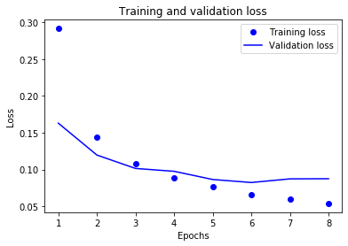

```python
import matplotlib.pyplot as plt

acc = history_dict['accuracy']
val_acc = history_dict['val_accuracy']
loss = history_dict['loss']
val_loss = history_dict['val_loss']

epochs = range(1, len(acc) + 1)

# "bo" is for "blue dot"
plt.plot(epochs, loss, 'bo', label='Training loss')
# b is for "solid blue line"
plt.plot(epochs, val_loss, 'b', label='Validation loss')
plt.title('Training and validation loss')

plt.xlabel('Epochs')
plt.ylabel('Loss')
plt.legend()

plt.show()
```

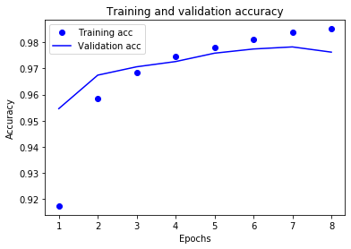

```python
plt.clf()   # clear figure
acc_values = history_dict['accuracy']
# val_acc_values = history_dict['val_acc']

plt.plot(epochs, acc, 'bo', label='Training acc')
plt.plot(epochs, val_acc, 'b', label='Validation acc')
plt.title('Training and validation accuracy')

plt.xlabel('Epochs')
plt.ylabel('Accuracy')
plt.legend()

plt.show()
```

## Confusion matrix

Let us see what the confusion matrix looks like. Using both `sklearn.metrics` and `tensorflow`. Then we visualize the confusion matrix and see what that tells us.

```python
# Get the predicted classes:
pred_classes = best_model.predict_classes(train_images)
```

```python
from sklearn.metrics import confusion_matrix

conf_max = confusion_matrix(train_labels,pred_classes)
conf_max
```

```
array([[5409,    0,    3,    3,    3,    9,    4,    1,   10,    2],
       [   1, 6123,   13,    5,   10,    0,    4,    5,   14,    4],
       [  10,   11, 5368,   24,   11,    6,    4,    6,   24,    6],
       [   2,    0,   14, 5549,    0,   21,    0,    4,   38,   10],
       [   2,    2,    3,    1, 5241,    3,   10,    3,    7,   35],
       [   5,    2,    4,   23,    3, 4905,   16,    1,   21,    7],
       [  11,    4,    2,    2,    8,    8, 5376,    0,    6,    0],
       [   2,   16,   20,   11,   13,   10,    0, 5591,   13,   39],
       [   5,    9,    8,    6,    2,   10,    4,    0, 5335,   10],
       [   9,    2,    0,   15,   27,   23,    1,   14,   11, 5352]])
```

```python
row_sums = conf_max.sum(axis=1, keepdims=True)
norm_conf_max = conf_max / row_sums
```

Looks like there were 38 threes confused as eights. You can see this in the heat map for the error below.

## Visualizing the confusion matrix

We use code from chapter 3 of Hands on Machine Learning (A. Geron) (cf. https://github.com/ageron/handson-ml2/blob/master/03_classification.ipynb) to display a "heat map" of the confusion matrix. Then we normalize the confusion matrix so we can compare error rates.

See https://learning.oreilly.com/library/view/hands-on-machine-learning/9781492032632/ch03.html#classification_chapter

```python
def plot_confusion_matrix(matrix):
    """If you prefer color and a colorbar"""
    fig = plt.figure(figsize=(8,8))
    ax = fig.add_subplot(111)
    cax = ax.matshow(matrix)
    fig.colorbar(cax)
```

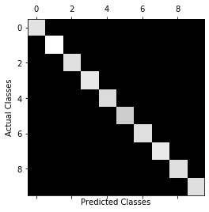

```python
import matplotlib.pyplot as plt

plt.matshow(conf_max, cmap=plt.cm.gray)
plt.xlabel("Predicted Classes")
plt.ylabel("Actual Classes")
# plt.savefig("confusion_matrix_plot_mnist", tight_layout=False)
plt.show()
```

The confusion matrix looks better than the one in in the previous experiments, doesn' it? Let us normalize the confusion matrix to get the error rates.

```python
row_sums = conf_max.sum(axis=1, keepdims=True)
norm_conf_max = conf_max / row_sums
```

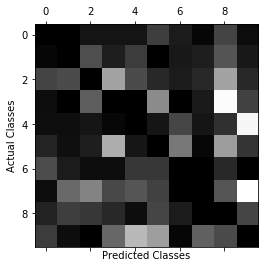

```python
import matplotlib.pyplot as plt
np.fill_diagonal(norm_conf_max, 0)
plt.matshow(norm_conf_max, cmap=plt.cm.gray)
plt.xlabel("Predicted Classes")
plt.ylabel("Actual Classes")
# plt.savefig("confusion_matrix_errors_plot_mnist_val", tight_layout=False)
plt.show()
```

Looks like a lot of digits were still misclassified as 8's. Let's plot examples of 3's and 8's to try to determine what went wrong here.

```python
def plot_digits(instances, pos, images_per_row=5, **options):
    size = 28
    images_per_row = min(len(instances), images_per_row)
    images = [instance.reshape(size,size) for instance in instances]
    n_rows = (len(instances) - 1) // images_per_row + 1
    row_images = []
    n_empty = n_rows * images_per_row - len(instances)
    images.append(np.zeros((size, size * n_empty)))
    for row in range(n_rows):
        rimages = images[row * images_per_row : (row + 1) * images_per_row]
        row_images.append(np.concatenate(rimages, axis=1))
    image = np.concatenate(row_images, axis=0)
    pos.imshow(image, cmap = 'binary', **options)
    pos.axis("off")
```

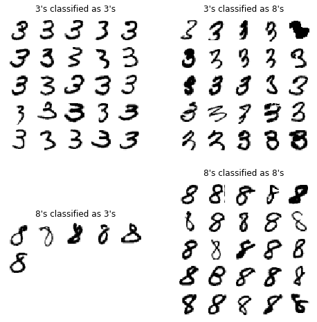

```python
cl_a, cl_b = 3,8
X_aa = train_images[(train_labels == cl_a) & (pred_classes == cl_a)]
X_ab = train_images[(train_labels == cl_a) & (pred_classes == cl_b)]
X_ba = train_images[(train_labels == cl_b) & (pred_classes == cl_a)]
X_bb = train_images[(train_labels == cl_b) & (pred_classes == cl_b)]

plt.figure(figsize=(8,8))

p1 = plt.subplot(221)
p2 = plt.subplot(222)
p3 = plt.subplot(223)
p4 = plt.subplot(224)

plot_digits(X_aa[:25], p1, images_per_row=5);
plot_digits(X_ab[:25], p2, images_per_row=5);
plot_digits(X_ba[:25], p3, images_per_row=5);
plot_digits(X_bb[:25], p4, images_per_row=5);


p1.set_title(f"{cl_a}'s classified as {cl_a}'s")
p2.set_title(f"{cl_a}'s classified as {cl_b}'s")
p3.set_title(f"{cl_b}'s classified as {cl_a}'s")
p4.set_title(f"{cl_b}'s classified as {cl_b}'s")

# plt.savefig("error_analysis_digits_plot_EXP1_valid")

plt.show()
```

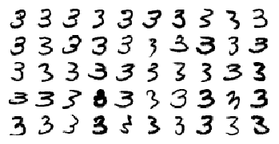

```python
# display 50 of the 3's classified correctly
plot_digits(X_aa[:50],plt,images_per_row = 10)
```

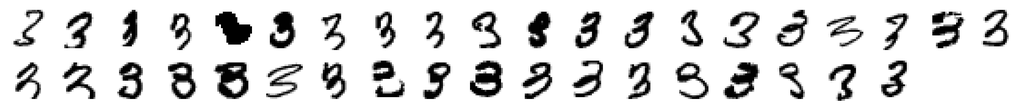

```python
# display all the 3's classified as 8's
num = X_ab.shape[0]
plt.figure(figsize=(50,50))
plot_digits(X_ab[:num],plt, images_per_row = 20)
```

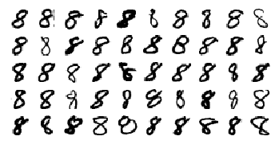

```python
# display 50 of the 8's classified correctly
plot_digits(X_bb[:50],plt, images_per_row = 10)
```

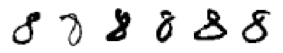

```python
# display all the 8's classified as 3's
num = X_ba.shape[0]
plt.figure(figsize=(10,10))
plot_digits(X_ba[:num],plt, images_per_row = 30)
```